# Analisis_Exploratorio

Irving, Chuy

2025-02-26

En este documento se realiza un breve analisis exploratorio sobre la base de datos provista (`train.csv`).

```
##        Id           MSSubClass      MSZoning          LotFrontage
##  Min.   :   1.0   Min.   : 20.0   Length:1460        Min.   : 21.00
##  1st Qu.: 365.8   1st Qu.: 20.0   Class :character   1st Qu.: 59.00
##  Median : 730.5   Median : 50.0   Mode  :character   Median : 69.00
##  Mean   : 730.5   Mean   : 56.9                      Mean   : 70.05
##  3rd Qu.:1095.2   3rd Qu.: 70.0                      3rd Qu.: 80.00
##  Max.   :1460.0   Max.   :190.0                      Max.   :313.00
##                                                      NA's   :259
##     LotArea          Street             Alley             LotShape
##  Min.   :  1300   Length:1460        Length:1460        Length:1460
##  1st Qu.:  7554   Class :character   Class :character   Class :character
##  Median :  9478   Mode  :character   Mode  :character   Mode  :character
##  Mean   : 10517
##  3rd Qu.: 11602
##  Max.   :215245
##
##  LandContour         Utilities          LotConfig          LandSlope
##  Length:1460        Length:1460        Length:1460        Length:1460
##  Class :character   Class :character   Class :character   Class :character
##  Mode  :character   Mode  :character   Mode  :character   Mode  :character
##
##
##
##
##  Neighborhood        Condition1         Condition2          BldgType
##  Length:1460        Length:1460        Length:1460        Length:1460
##  Class :character   Class :character   Class :character   Class :character
##  Mode  :character   Mode  :character   Mode  :character   Mode  :character
##
##
##
##
##   HouseStyle         OverallQual      OverallCond      YearBuilt
##  Length:1460        Min.   : 1.000   Min.   :1.000   Min.   :1872
##  Class :character   1st Qu.: 5.000   1st Qu.:5.000   1st Qu.:1954
##  Mode  :character   Median : 6.000   Median :5.000   Median :1973
##                     Mean   : 6.099   Mean   :5.575   Mean   :1971
##                     3rd Qu.: 7.000   3rd Qu.:6.000   3rd Qu.:2000
##                     Max.   :10.000   Max.   :9.000   Max.   :2010
##
```

[output cut: 113 more lines]

```
##  Min.   : 1.000   Min.   :2006   Length:1460        Length:1460
##  1st Qu.: 5.000   1st Qu.:2007   Class :character   Class :character
##  Median : 6.000   Median :2008   Mode  :character   Mode  :character
##  Mean   : 6.322   Mean   :2008
##  3rd Qu.: 8.000   3rd Qu.:2009
##  Max.   :12.000   Max.   :2010
##
##    SalePrice
##  Min.   : 34900
##  1st Qu.:129975
##  Median :163000
##  Mean   :180921
##  3rd Qu.:214000
##  Max.   :755000
##
```

### Descripcion de las variables numericas

Tabla de Variables Cuantitativas

| Variable | Descripcion | Tipo de Dato |
| --- | --- | --- |
| LotFrontage | Pies lineales de calle conectada a la propiedad | Flotante |
| LotArea | Tamanio del lote en pies cuadrados | Entero |
| OverallQual | Califica el material general y el acabado | Entero |
| OverallCond | Califica la condicion general | Entero |
| YearBuilt | Fecha de construccion original | Entero |
| YearRemodAdd | Fecha de remodelacion | Entero |
| MasVnrArea | area de revestimiento de mamposteria en pies cuadrados | Flotante |
| BsmtFinSF1 | Pies cuadrados terminados tipo 1 | Entero |
| BsmtFinSF2 | Pies cuadrados terminados tipo 2 | Entero |
| BsmtUnfSF | Pies cuadrados sin terminar del area del sotano | Entero |
| TotalBsmtSF | Pies cuadrados totales del sotano | Entero |
| 1stFlrSF | Pies cuadrados del primer piso | Entero |
| 2ndFlrSF | Pies cuadrados del segundo piso | Entero |
| LowQualFinSF | Pies cuadrados de acabado de baja calidad | Entero |
| GrLivArea | area habitable sobre rasante en pies cuadrados | Entero |
| BsmtFullBath | Banios completos en el sotano | Entero |
| BsmtHalfBath | Medios banios en el sotano | Entero |
| FullBath | Banios completos por encima del rasante | Entero |
| HalfBath | Medios banios por encima del rasante | Entero |
| BedroomAbvGr | Dormitorios por encima del rasante | Entero |
| KitchenAbvGr | Cocinas por encima del rasante | Entero |
| TotRmsAbvGrd | Total de habitaciones por encima del rasante (no incluye banios) | Entero |
| Fireplaces | Numero de chimeneas | Entero |
| GarageYrBlt | Anio de construccion del garaje | Entero |
| GarageCars | Tamanio del garaje en capacidad de coches | Entero |
| GarageArea | Tamanio del garaje en pies cuadrados | Entero |
| WoodDeckSF | area de la cubierta de madera en pies cuadrados | Entero |
| OpenPorchSF | area del porche abierto en pies cuadrados | Entero |
| EnclosedPorch | area del porche cerrado en pies cuadrados | Entero |
| 3SsnPorch | Porche de tres temporadas en pies cuadrados | Entero |
| ScreenPorch | Porche de pantalla en pies cuadrados | Entero |
| PoolArea | area de la piscina en pies cuadrados | Entero |
| MiscVal | Valor de caracteristicas miscelaneas | Entero |
| MoSold | Mes de la venta | Entero |
| YrSold | Anio de la venta | Entero |
| SalePrice | Precio de la venta | Entero |

### Descripcion de las variables categoricas

Variables Categoricas y sus Descripciones en Espaniol

| Variable | Descripcion |
| --- | --- |
| MSSubClass | Identifica el tipo de vivienda involucrada en la venta. |
| MSZoning | Identifica la clasificacion general de zonificacion de la venta. |
| Street | Tipo de acceso a la propiedad por carretera. |
| Alley | Tipo de acceso a la propiedad por callejon. |
| LotShape | Forma general del terreno. |
| LandContour | Planitud del terreno. |
| Utilities | Tipo de servicios publicos disponibles. |
| LotConfig | Configuracion del terreno. |
| LandSlope | Pendiente del terreno. |
| Neighborhood | Ubicaciones fisicas dentro de los limites de la ciudad de Ames. |
| Condition1 | Proximidad a varias condiciones. |
| Condition2 | Proximidad a varias condiciones (si hay mas de una presente). |
| BldgType | Tipo de vivienda. |
| HouseStyle | Estilo de la vivienda. |
| RoofStyle | Tipo de techo. |
| RoofMatl | Material del techo. |
| Exterior1st | Revestimiento exterior principal de la casa. |
| Exterior2nd | Revestimiento exterior secundario de la casa (si hay mas de un material). |
| MasVnrType | Tipo de revestimiento de mamposteria. |
| ExterQual | Evalua la calidad del material en el exterior. |
| ExterCond | Evalua la condicion actual del material en el exterior. |
| Foundation | Tipo de cimentacion. |
| BsmtQual | Evalua la altura del sotano. |
| BsmtCond | Evalua la condicion general del sotano. |
| BsmtExposure | Se refiere a paredes a nivel de salida o jardin. |
| BsmtFinType1 | Calificacion del area terminada del sotano (area 1). |
| BsmtFinType2 | Calificacion del area terminada del sotano (area 2). |
| Heating | Tipo de calefaccion. |
| HeatingQC | Calidad y condicion de la calefaccion. |
| CentralAir | Aire acondicionado central. |
| Electrical | Sistema electrico. |
| KitchenQual | Calidad de la cocina. |
| Functional | Funcionalidad de la vivienda. |
| FireplaceQu | Calidad de la chimenea. |
| GarageType | Ubicacion del garaje. |
| GarageFinish | Acabado interior del garaje. |
| GarageQual | Calidad del garaje. |
| GarageCond | Condicion del garaje. |
| PavedDrive | Pavimentacion del acceso. |
| PoolQC | Calidad de la piscina. |
| Fence | Calidad de la cerca. |
| MiscFeature | Caracteristica miscelanea no cubierta en otras categorias. |
| SaleType | Tipo de venta. |
| SaleCondition | Condicion de la venta. |

Ademas de describir las variables numericas, tambien nos tomamos la tarea de analizar las variables categoricas y determinar cuales de estas podrian ser relevantes para el precio de la casa. Tomamos como variables importantes el vecindario, calidad de la casa, calidad de la cocina y el tipo de garaje

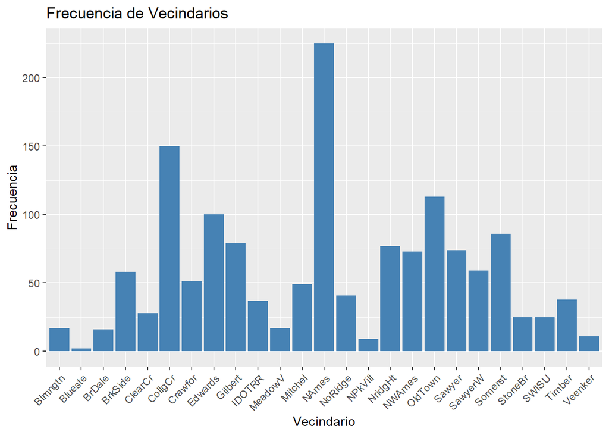

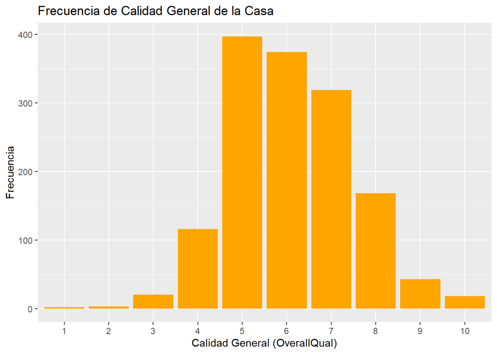

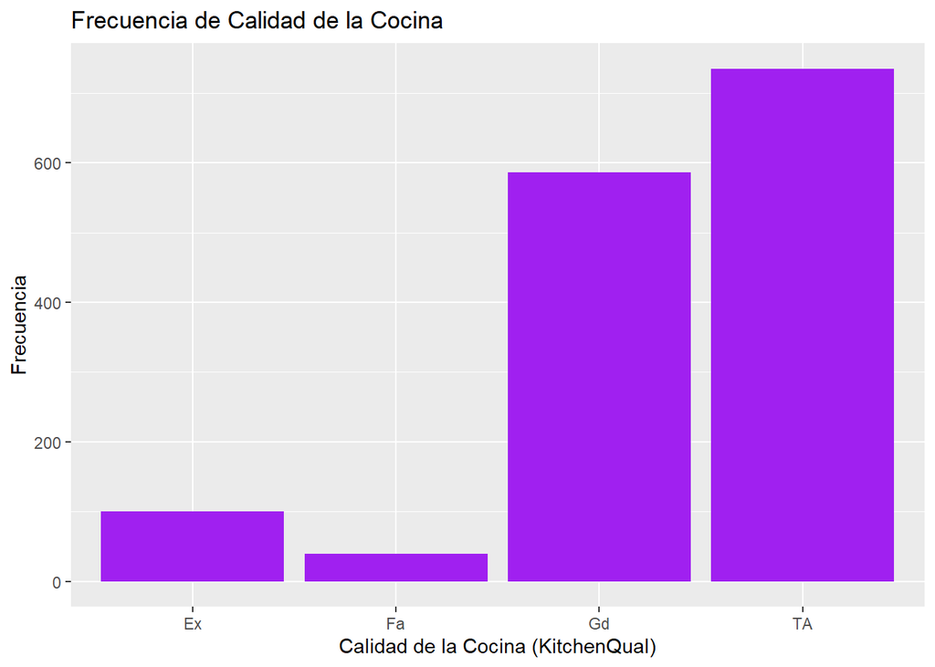

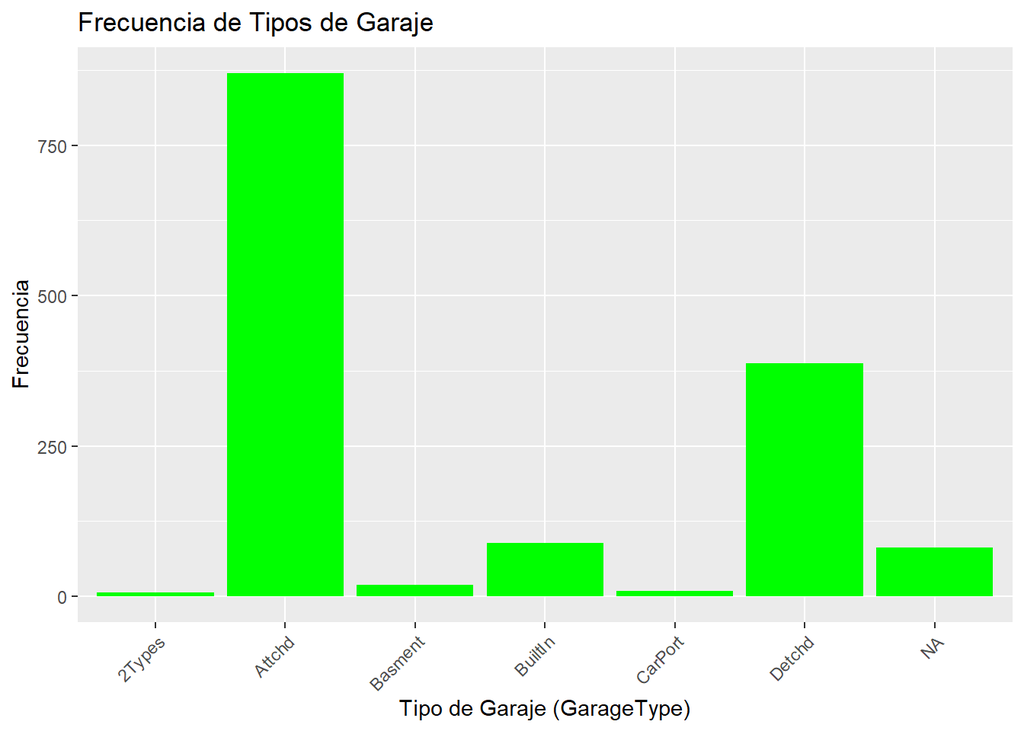

Algo interesante que podemos ver en estas graficas es la distribucion de las frecuencias. Viendo la calidad general de la casa podemos ver que la mayoria de las casas son “promedio” o “mejor al promedio”. Esto lo sabemos porque la calidad de la casa es una escala del 1 al 10:

10 Very Excellent 9 Excellent 8 Very Good 7 Good 6 Above Average 5 Average 4 Below Average 3 Fair 2 Poor 1 Very Poo

Esto se puede ver dentro de la grafica de la calidad de la cocina, donde se puede ver que predominan las cocinas Gd y TA (Good u Typocal/Average). Lo que quiere decir que nuestro set de datos tiene varias casas que son buenas o promedio y pocas casas que son malas o muy buenas.

Una vez hecho esto haremos un analisis por grupos (clustering) para poder hacer mas insights sobre los datos.

```
## [1] "Estadistico de Hopkins: 0.999999999977175"
```

## Grafico de codo para saber el numero de clusters.

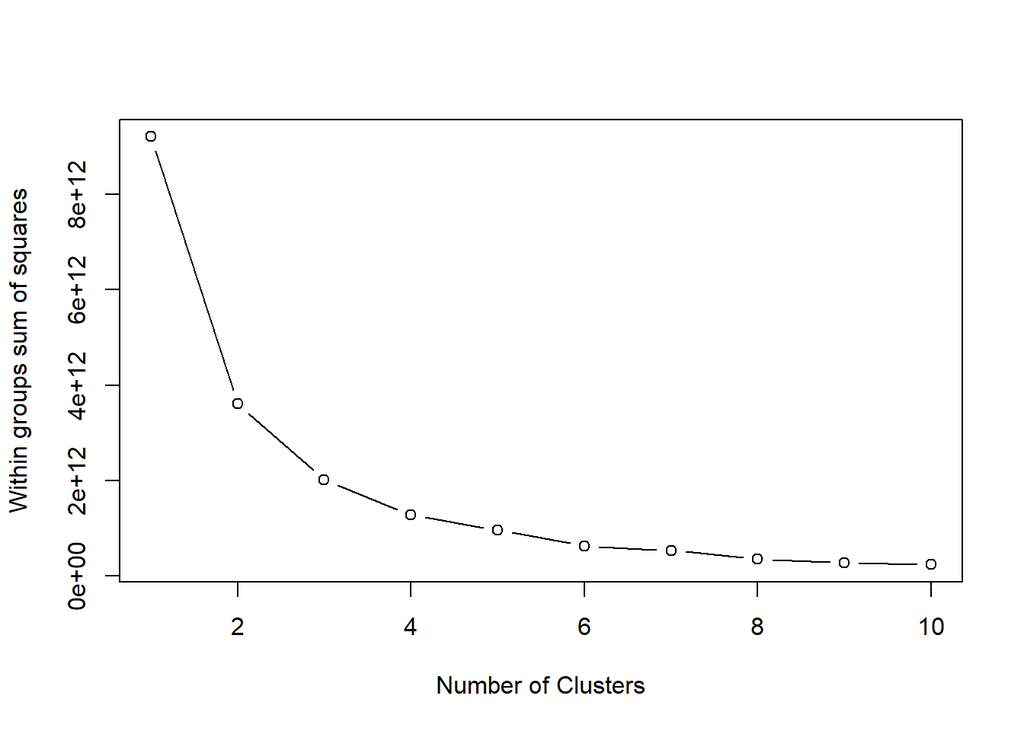

Con este resultaod podemos concluir que se pueden hacer 3 o 4 clusters. Ahora usando K-Means, podemos probar a hacer el agrupamiento.

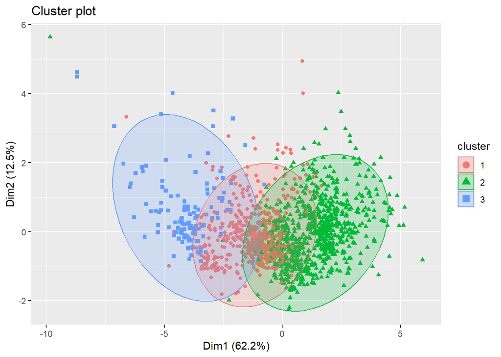

Evaluando los resultados del clustering con el metodo de silueta se obtiene lo siguiente:

```
## [1] "Coeficiente de silueta promedio: 0.561394235799686"
```

Se ha obtenido un valor mayor a 0.5, por lo que podemos decir que el agrupammiento a sido exitoso. Ahora para terminar el analisis de grupos, es pueden analizar los datos nuevamente pero ahora evaluando de forma grupal por los clusters. Estas son algunas grafiacs que nos ayudaron a determinar el significado de los grupos realizados por el algoritmo de kmeans.

```
## # A tibble: 3 × 2
##   Cluster Precio_Medio
##   <fct>          <dbl>
## 1 1            215390.
## 2 2            129105.
## 3 3            373287.
```

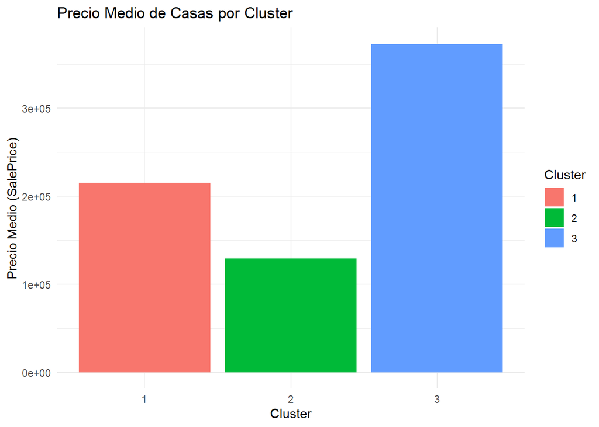

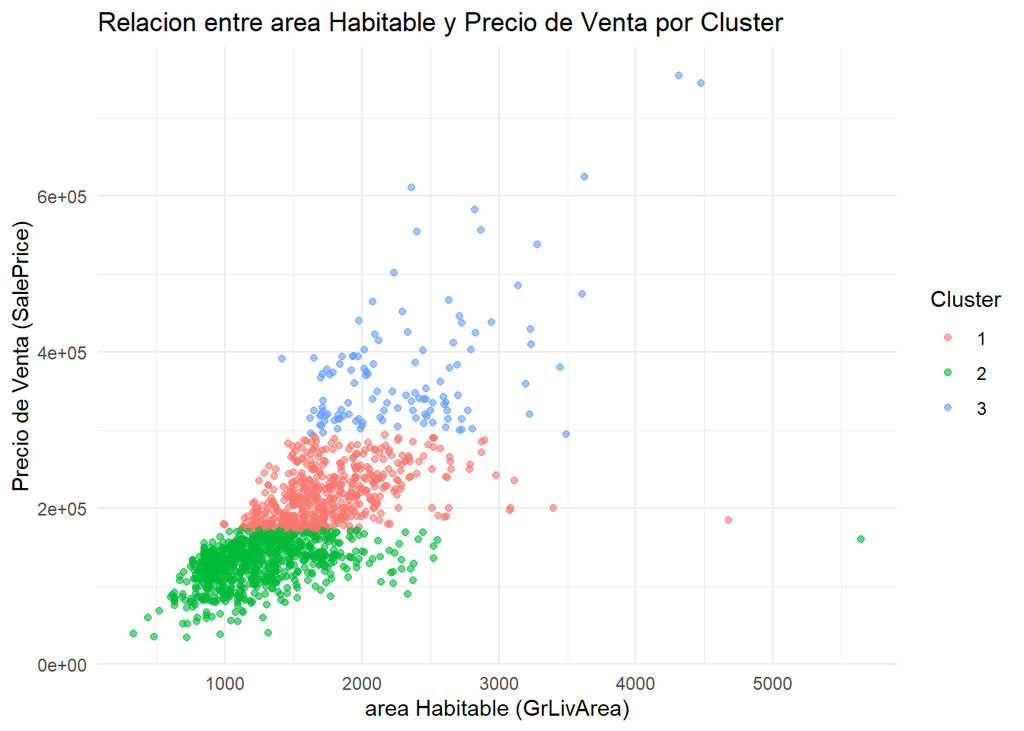

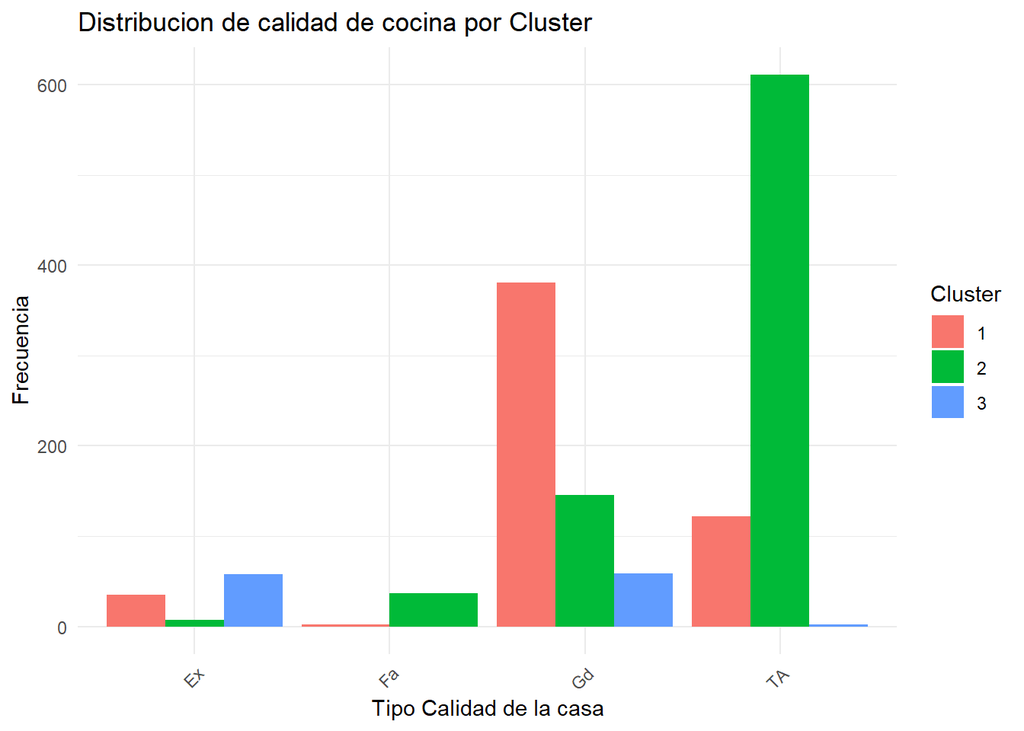

Con estos resultados finalmente podemos concluir que el clustering realizado fue exitosos y las casas fueron separadas principalmente por la calidad. Habiendo claramente 3 grupos, donde se tienen casas de menor precio y menor calidad, casa regulares y casas caras de muy alta calidad. Esto se ve en los graficos realizados. Es mas, el grafico donde la separacion se ve casi perfecta es la relacion entre el area habitable y el precio de la casa. Definitivamente esta sera una variable que crucial que determina el valor de la propiedad. Relacionandolo con las variables ctegoricas tambien se puede ver que esta separacion fue correcta. Las casas del grupo 2 (las casas de menor valoracion), son las que tienen una cocina promedio y luego con las cocinas buenas y excelentes es cuando el cluster 1 (casas de precio intermedia) y el cluster 3 comienzan a tener mayor presencia, ya que son casas que tienen mejor calidad en general, incluyendo la cocina. Y con la grafica que se muestra a continuacion se confirma lo afirmado previamente.

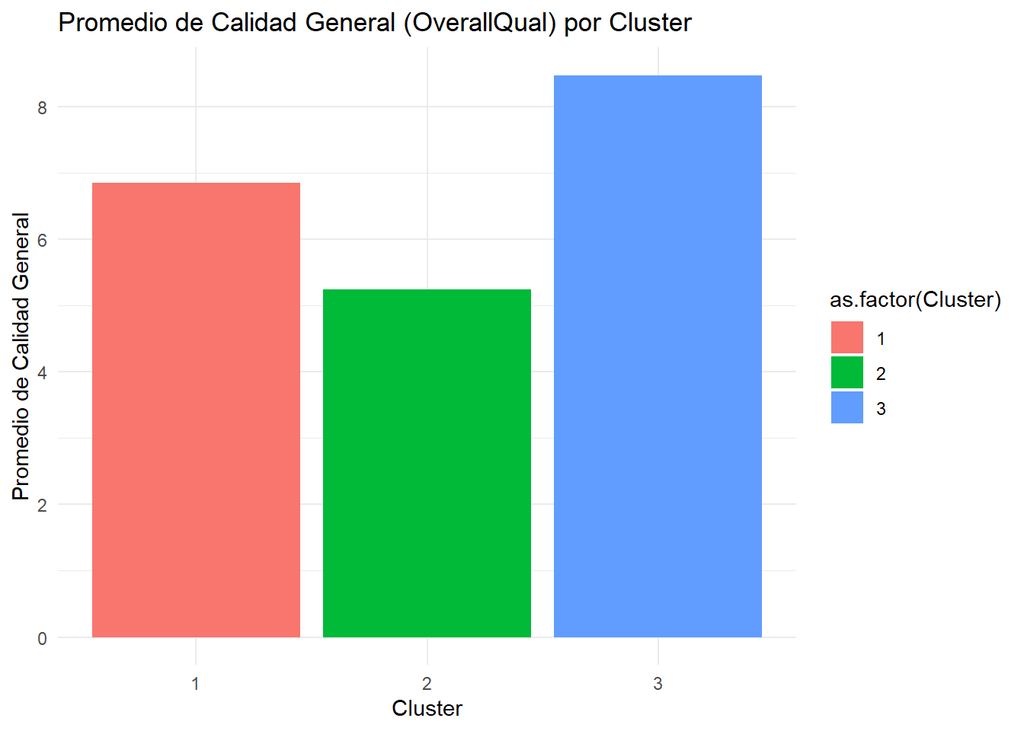

En este documento se realiza tambien la division de informacion para el training y testing. Estaremos utilizando 70% training y 30% de testing, tomando como columna objetivo el precio de una casa. En este caso no tenemos los datos balanceados, pero esto no es un problema. Realmente el objetivo principal de nuestro modelo es buscar predecir el precio de una casa, por lo que no tenemos una clasificacion binaria para tener exactamaente la misma cantidad de registros para un caso u otro. Siendo nuestra columna objetivo el precio de la casa, habrian muchos casos de clasificacion. Por lo que podemos hacer la muestra y division sin mayores complicaciones. Usamos 70% -30% ya que es lo que se recomienda generalmente para el entrenamiento de modelos de regresion lineal.